# Decision tree with PSA (Jenks 2016)

Tegaderm CHG IV Securement Dressing

Andrew J. Sims

July 2020

# Introduction

This vignette is an example of modelling a decision tree using the `rdecision` package, with probabilistic sensitivity analysis. It is based on the model reported by Jenks *et al*<sup>1</sup> in which a transparent dressing used to secure vascular catheters (Tegaderm CHG) was compared with a standard dressing.

# Model variables

## Source variables

- For variables with lognormal uncertainty, the manufacturer synthesized a log normal distribution as $\exp(\alpha + \beta r())$ where $r()$ is a random draw from a standard normal distribution. This does not follow the parametrizations of the `LogNormModVar` provided in `rdecision`, but can be reproduced using expression model variables. Three standard normal model variables were introduced for this purpose.
- The values for $\alpha$ and $\beta$ for the hazard ratio for CRBSI and LSI were -0.911 and -0.393 respectively, and 1.482 and 0.490 for the relative risk of dermatitis.
- The probabilities of CRBSI and LSI for standard dressings ($p$) were modified by the hazard ratio for Tegaderm using the form $(1-(1-p)^h)$ where $h$ is the hazard ratio. Relative risks were applied as multipliers.
- The point estimate cost of CRBSI was £9900, not £9990, although the parameters (198,50) are quoted correctly.

The model variables were constructed as follows:

```r
# standard normals
n1 <- NormModVar$new("SN1","", 0, 1)
n2 <- NormModVar$new("SN2","", 0, 1)
n3 <- NormModVar$new("SN3","", 0, 1)

# clinical variables
r.CRBSI <- NormModVar$new(
  'Baseline CRBSI rate', '/1000 catheter days', mu=1.48, sigma=0.074
)
hr.CRBSI <- ExprModVar$new(
  "Tegaderm CRBSI HR",
  "HR",
  rlang::quo(exp(-0.911-0.393*n1))
)
hr.LSI <- ExprModVar$new(
  "Tegaderm LSI HR",
  "HR",
  rlang::quo(exp(-0.911-0.393*n2))
)
r.Dermatitis <- NormModVar$new(
  'Baseline dermatitis risk', '/catheter', mu=0.0026, sigma=0.00026
)
rr.Dermatitis <- ExprModVar$new(
  "Tegaderm LSI HR",
  "HR",
  rlang::quo(exp(1.482-0.490*n3))
)

# cost variables
c.CRBSI <- GammaModVar$new(
  'CRBSI cost', 'GBP', shape=198.0, scale=50
)
c.Dermatitis <- GammaModVar$new(
  'Dermatitis cost', 'GBP', shape=30, scale=5
)
c.LSI <- GammaModVar$new(
  'LSI cost', 'GBP', shape=50, scale=5
)
n.catheters <- NormModVar$new(
  'No. catheters', 'catheters', mu=3, sigma=0.3
)
c.Tegaderm <- ExprModVar$new(
  "Tegaderm CHG cost", "GBP", rlang::quo(6.21*n.catheters)
)
c.Standard <- ExprModVar$new(
  "Standard dressing cost", "GBP", rlang::quo(1.34*n.catheters)
)
n.cathdays <- NormModVar$new(
  'No. days with catheter', 'days', mu=10, sigma=2
)
```

## Model variable expressions

Variables in the model may be included in the decision tree via mathematical expressions, which involve model variables and are themselves model variables. Forms of expression involving R functions and multiple model variables are supported, provided they conform to R syntax. The following code creates the model variable expressions to be used as values in the decision tree edges. For probabilities, the convention $q = 1-p$ is used to ensure that the sum of probabilities leaving each chance is one.

```r
# probabilities
p.Dermatitis.S <- ExprModVar$new(
  'P(dermatitis|standard dressing)', 'P',
  rlang::quo(r.Dermatitis*n.catheters)
)
q.Dermatitis.S <- ExprModVar$new(
  'Q(dermatitis|standard dressing)', '1-P',
  rlang::quo(1-p.Dermatitis.S)
)
p.Dermatitis.T <- ExprModVar$new(
  'P(dermatitis|Tegaderm)', 'P',
  rlang::quo(r.Dermatitis*rr.Dermatitis*n.catheters)
)
q.Dermatitis.T <- ExprModVar$new(
  'Q(dermatitis|Tegaderm)', '1-P',
  rlang::quo(1-p.Dermatitis.T)
)

p.LSI.S <- NormModVar$new(
  'P(LSI|Standard)', '/patient', mu=0.1, sigma=0.01
)
q.LSI.S <- ExprModVar$new(
  'Q(LSI|Standard)', '1-P', rlang::quo(1-p.LSI.S)
)
p.LSI.T <- ExprModVar$new(
  'P(LSI|Tegaderm)', 'P', rlang::quo(1-(1-p.LSI.S)^hr.LSI)
)
q.LSI.T <- ExprModVar$new(
  'Q(LSI|Tegaderm)', '1-P', rlang::quo(1-p.LSI.T)
)

p.CRBSI.S <- ExprModVar$new(
  'P(CRBSI|standard dressing)', 'P',  rlang::quo(r.CRBSI*n.cathdays/1000)
)
q.CRBSI.S <- ExprModVar$new(
  'Q(CRBSI|standard dressing)', '1-P',  rlang::quo(1-p.CRBSI.S)
)
p.CRBSI.T <- ExprModVar$new(
  'P(CRBSI|Tegaderm)', 'P', rlang::quo(1-(1-r.CRBSI*n.cathdays/1000)^hr.CRBSI)
)
q.CRBSI.T <- ExprModVar$new(
  'Q(CRBSI|Tegaderm)', '1-P', rlang::quo(1-p.CRBSI.T)
)
```

# The decision tree

## Constructing the tree

The following code constructs the decision tree based on Figure 2 of Jenks *et al*.<sup>1</sup> In the formulation used by `rdecision`, the decision tree is constructed from sets of decision, chance and leaf nodes and from edges (actions and reactions). Leaf nodes are synonymous with pathways in Briggs’ terminology.<sup>2</sup> The time horizon is not stated explicitly in the model, and is assumed to be 7 days. It was implied that the time horizon was ICU stay plus some follow-up, and the costs reflect those incurred in that period, so the assumption of 7 days does not affect the `rdecision` implementation of the model.

The tree is somewhat more complex than Figure 2 of Jenks *et al* because it allows for patients to have more than one adverse event (AE) during their stay (whereas their Figure 2 implies that only one event per patient is possible). The rates of AE were estimated independently, and allow for multiple events, see figure.

```r
# create decision tree
th <- as.difftime(7, units="days")
# standard dressing
t01 <- LeafNode$new("t01", interval=th)
t02 <- LeafNode$new("t02", interval=th)
c01 <- ChanceNode$new()
e01 <- Reaction$new(c01,t01,p=p.Dermatitis.S,cost=c.Dermatitis,
                    label="Dermatitis")
e02 <- Reaction$new(c01,t02,p=q.Dermatitis.S,cost=0,
                    label="No dermatitis")
#
t03 <- LeafNode$new("t03", interval=th)
t04 <- LeafNode$new("t04", interval=th)
c02 <- ChanceNode$new()
e03 <- Reaction$new(c02,t03,p=p.Dermatitis.S,cost=c.Dermatitis,
                    label="Dermatitis")
e04 <- Reaction$new(c02,t04,p=q.Dermatitis.S,cost=0,
                    label="No dermatitis")
#
c03 <- ChanceNode$new()
e05 <- Reaction$new(c03,c01,p=p.LSI.S,cost=c.LSI,label="LSI")
e06 <- Reaction$new(c03,c02,p=q.LSI.S,cost=0,label="No LSI")
#
t11 <- LeafNode$new("t11", interval=th)
t12 <- LeafNode$new("t12", interval=th)
c11 <- ChanceNode$new()
e11 <- Reaction$new(c11,t11,p=p.Dermatitis.S,cost=c.Dermatitis,
                    label="Dermatitis")
e12 <- Reaction$new(c11,t12,p=q.Dermatitis.S,cost=0,label="No Dermatitis")
#
t13 <- LeafNode$new("t13", interval=th)
t14 <- LeafNode$new("t14", interval=th)
c12 <- ChanceNode$new()
e13 <- Reaction$new(c12,t13,p=p.Dermatitis.S,cost=c.Dermatitis,
                    label="Dermatitis")
e14 <- Reaction$new(c12,t14,p=q.Dermatitis.S,cost=0,label="No dermatitis")
#
c13 <- ChanceNode$new()
e15 <- Reaction$new(c13,c11,p=p.LSI.S,cost=c.LSI,label="LSI")
e16 <- Reaction$new(c13,c12,p=q.LSI.S,cost=0,label="No LSI")
#
c23 <- ChanceNode$new()
e21 <- Reaction$new(c23,c03,p=p.CRBSI.S,cost=c.CRBSI,label="CRBSI")
e22 <- Reaction$new(c23,c13,p=q.CRBSI.S,cost=0,label="No CRBSI")
#
# Tegaderm branch
t31 <- LeafNode$new("t31", interval=th)
t32 <- LeafNode$new("t32", interval=th)
c31 <- ChanceNode$new()
e31 <- Reaction$new(c31,t31,p=p.Dermatitis.T,cost=c.Dermatitis,
                    label="Dermatitis")
e32 <- Reaction$new(c31,t32,p=q.Dermatitis.T,cost=0,label="no dermatitis")
#
t33 <- LeafNode$new("t33", interval=th)
t34 <- LeafNode$new("t34", interval=th)
c32 <- ChanceNode$new()
e33 <- Reaction$new(c32,t33,p=p.Dermatitis.T,cost=c.Dermatitis,
                    label="Dermatitis")
e34 <- Reaction$new(c32,t34,p=q.Dermatitis.T,cost=0,label="No dermatitis")
#
c33 <- ChanceNode$new()
e35 <- Reaction$new(c33,c31,p=p.LSI.T,cost=c.LSI,label="LSI")
e36 <- Reaction$new(c33,c32,p=q.LSI.T,cost=0,label="No LSI")
#
t41 <- LeafNode$new("t41", interval=th)
t42 <- LeafNode$new("t42", interval=th)
c41 <- ChanceNode$new()
e41 <- Reaction$new(c41,t41,p=p.Dermatitis.T,cost=c.Dermatitis,
                    label="Dermatitis")
e42 <- Reaction$new(c41,t42,p=q.Dermatitis.T,cost=0,label="No dermatitis")
#
t43 <- LeafNode$new("t43", interval=th)
t44 <- LeafNode$new("t44", interval=th)
c42 <- ChanceNode$new()
e43 <- Reaction$new(c42,t43,p=p.Dermatitis.T,cost=c.Dermatitis,
                    label="Dermatitis")
e44 <- Reaction$new(c42,t44,p=q.Dermatitis.T,cost=0,label="No dermatitis")
#
c43 <- ChanceNode$new()
e45 <- Reaction$new(c43,c41,p=p.LSI.T,cost=c.LSI,label="LSI")
e46 <- Reaction$new(c43,c42,p=q.LSI.T,cost=0,label="No LSI")
#
c53 <- ChanceNode$new()
e51 <- Reaction$new(c53,c43,p=p.CRBSI.T,cost=c.CRBSI,label="CRBSI")
e52 <- Reaction$new(c53,c33,p=q.CRBSI.T,cost=0,label="no CRBSI")
#
# decision node
d1 <- DecisionNode$new("d1")
e9 <- Action$new(d1,c23,label="Standard",cost=c.Standard)
e10 <- Action$new(d1,c53,label="Tegaderm",cost=c.Tegaderm)
#
# create decision tree
V <- list(d1,c01,c02,c03,c11,c12,c13,c23,c31,c32,c33,c41,c42,c43,c53,
          t01,t02,t03,t04,t11,t12,t13,t14,t31,t32,t33,t34,t41,t42,t43,t44)
E <- list(e01,e02,e03,e04,e05,e06,e11,e12,e13,e14,e15,e16,e21,e22,
          e31,e32,e33,e34,e35,e36,e41,e42,e43,e44,e45,e46,e51,e52,e9,e10)
DT <- DecisionTree$new(V,E)
```

## Tree diagram

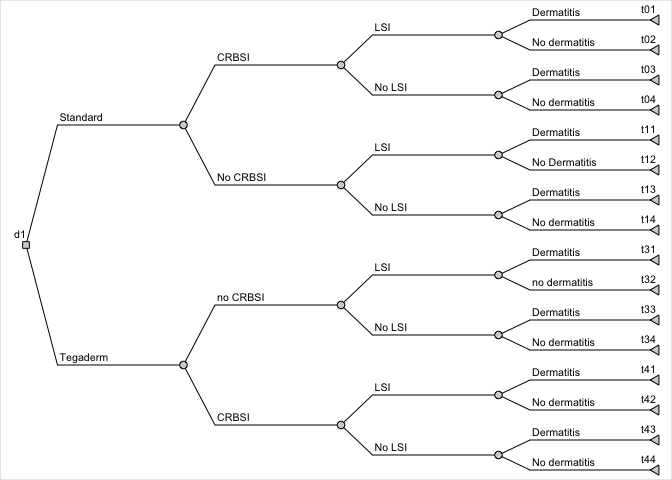

Decision tree for the Tegaderm model

In the manufacturer’s model, the uncertainties in the probabilities associated with the polytomous chance nodes were modelled as independent variables. This is not recommended because there is a chance that a particular run of the PSA will yield probabilities that are outside the range [0,1].

## Summary of model variables in the tree

The model variables which will be associated with actions, reactions and leaf nodes can be tabulated using the method `modvar_table`. This returns a data frame describing each variable, its description, units and uncertainty distribution. Variables inheriting from type `ModVar` will be included in the tabulation unless explicitly excluded, regular numeric values will not be listed. In the Tegaderm model, the input model variables are in the following table, with expression model variables excluded. Variables SN1, SN2 and SN3 were introduced to model the uncertainties of the hazard and risk ratios.

| Description | Distribution |
| --- | --- |
| Dermatitis cost | Ga(30,5) |
| Baseline dermatitis risk | N(0.0026,0.00026) |
| No. catheters | N(3,0.3) |
| LSI cost | Ga(50,5) |
| P(LSI\|Standard) | N(0.1,0.01) |
| CRBSI cost | Ga(198,50) |
| Baseline CRBSI rate | N(1.48,0.074) |
| No. days with catheter | N(10,2) |
| SN3 | N(0,1) |
| SN2 | N(0,1) |
| SN1 | N(0,1) |

## Point estimates and distributions of model variables

The point estimates, units and distributional properties are obtained from the same call, in the remaining columns.

| Variable | Mean | Q2.5 | Q97.5 |
| --- | --- | --- | --- |
| Dermatitis cost, GBP | 150 | 101 | 208 |
| Baseline dermatitis risk, /catheter | 0.0026 | 0.00209 | 0.00311 |
| No. catheters, catheters | 3 | 2.41 | 3.59 |
| LSI cost, GBP | 250 | 186 | 324 |
| P(LSI\|Standard), /patient | 0.1 | 0.0804 | 0.12 |
| CRBSI cost, GBP | 9900 | 8569 | 11326 |
| Baseline CRBSI rate, /1000 catheter days | 1.48 | 1.33 | 1.63 |
| No. days with catheter, days | 10 | 6.08 | 13.9 |
| SN3, | 0 | -1.96 | 1.96 |
| SN2, | 0 | -1.96 | 1.96 |
| SN1, | 0 | -1.96 | 1.96 |

# Running the model

## Base case

The following code runs a single model scenario, using the `evaluate` method of a decision node to evaluate each pathway from the decision node, shown in the table. This model did not consider utility, and the columns associated with utility are removed.

| Run | d1 | Cost |
| --- | --- | --- |
| 1 | Standard | 176.7 |
| 1 | Tegaderm | 93.33 |

## Univariate sensitivity analysis

The sensitivity of the decision tree results to each source model variable, varied independently of the others, is demonstrated by a tornado diagram. The method `tornado` can be used to generate such a plot (and also provides a tabulated version of the values used in the plot). Source variables are varied over their 95% confidence limits, see figure.

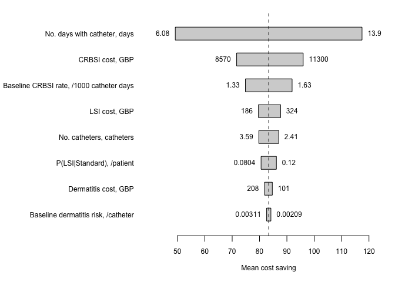

Tornado diagram for the Tegaderm model

## Probabilistic sensitivity analysis

Multivariate probabilistic sensitivity analysis is supported through the use of sampling model variables. The same call, with extra parameters, is used to run the PSA:

```r
N <- 1000
PSA <- DT$evaluate(setvars="random", N=N)
```

The first few runs of PSA are as follows (after reshaping the table to give one row per simulation, rather than one row per run, per strategy):

| Run | Cost.Tegaderm | Cost.Standard | Difference |
| --- | --- | --- | --- |
| 1 | 78.73 | 170.6 | -91.91 |
| 2 | 94.44 | 165.8 | -71.39 |
| 3 | 79.71 | 167.5 | -87.77 |
| 4 | 88.02 | 243.9 | -155.9 |
| 5 | 124.1 | 170.6 | -46.58 |
| 6 | 75.07 | 142.2 | -67.12 |
| 7 | 89.02 | 162.5 | -73.48 |
| 8 | 74.61 | 111 | -36.38 |
| 9 | 76.81 | 134.9 | -58.06 |
| 10 | 76.53 | 209.7 | -133.1 |

From PSA (1000 runs), the mean cost of treatment with Tegaderm was 99.21, the mean cost of treatment with standard dressings was 176.6 and the mean cost saving was -77.39. The 95% confidence interval for cost saving was -139.58 to -14.38; the standard deviation of the cost saving was 32.48. Overall, 98.9% of runs found that Tegaderm was cost saving. These results replicate those reported by the manufacturer (saving of 77.76, 98.5% cases cost saving; mean cost of standard dressing 176.89, mean cost of Tegaderm 99.63).

# References

1

Jenks M, Craig J, Green W, Hewitt N, Arber M, Sims AJ. Tegaderm CHG IV Securement Dressing for Central Venous and Arterial Catheter Insertion Sites: A NICE Medical Technology Guidance. *Applied Health Economics and Health Policy* 2016;**14**:135–49. https://doi.org/10.1007/s40258-015-0202-5.

2

Briggs A, Claxton K, Sculpher M. *Decision modelling for health economic evaluation*. Oxford, UK: Oxford University Press; 2006.